# Exercise quality prediction - Practical Manchine Learning Project

Iain Morgan

15 jan 2018

## Executive summary

This report describes the application of machine-learning to predict the manner in which a physical exercise was done. The data was sourced from a study to measure the quality of a weight-lifting exercise using sensors on the belt, forearm, arm and dumbell.

## Data sourcing and exploration

First, the data was sourced and examined, with DIV/0! values converted to NA:

```r
rawData <- read.csv("pml-training.csv",na.strings = c("NA","#DIV/0!"))
testData <- read.csv("pml-testing.csv",na.strings = c("NA","#DIV/0!"))
```

First, we plot the data by index and colouring by classification. The plot shows that the data is grouped by the index, X, so we need to exclude X as a predictor.

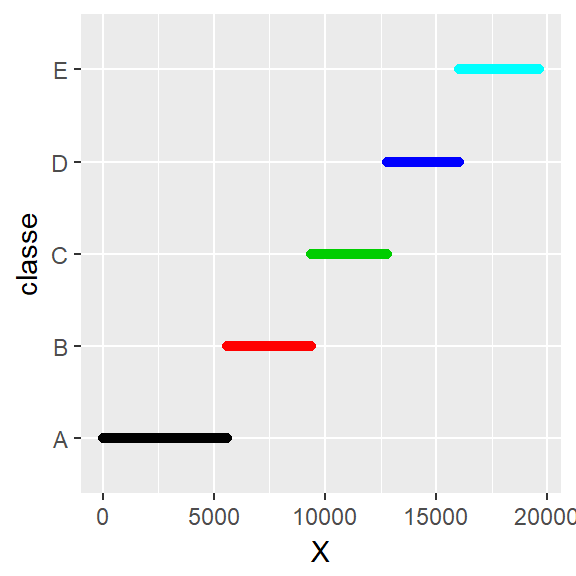

Plot of classe vs. index

```r
g <- ggplot(data = rawData, aes(x=X,y=classe))
g <- g + geom_point(color=as.numeric(rawData$classe))
g
```

Next, the training data was split into training and validation sets, so that the out of sample accuracy can be better tested. Given the large number of observations, this should not be a problem, and the final model will be trained on the whole training data for maximum accuracy.

At the same time, the “X” index is dropped from training, validation and testing sets, to avoid it being used as a predictor.

```r
trainSet <- createDataPartition(y=rawData$classe,times = 1,p=0.75,list=FALSE)
training <- rawData[trainSet,2:160]
validation <- rawData[-trainSet,2:160]
testing <- testData[2:160]
```

```r
cleanData <- function(x) {
  x$kurtosis_yaw_belt <- as.numeric(x$kurtosis_yaw_belt)
  x$skewness_yaw_belt <- as.numeric(x$skewness_yaw_belt)
  x$kurtosis_yaw_dumbbell <- as.numeric(x$kurtosis_yaw_dumbbell)
  x$skewness_yaw_dumbbell <- as.numeric(x$skewness_yaw_dumbbell)
  x$kurtosis_yaw_forearm <- as.numeric(x$kurtosis_yaw_forearm)
  x$skewness_yaw_forearm <- as.numeric(x$skewness_yaw_forearm)
  x$cvtd_timestamp <- as.POSIXct(x$cvtd_timestamp,format="%d/%m/%Y %H:%M")
  x
}

training <- cleanData(training)
validation <- cleanData(validation)
testing <- cleanData(testing)
```

On inspecting the data, it was found that many of the variables have a hign proportion of NAs, making them unsuitable as predictors. A quick function was run to remove variables with more than 10% NAs from the training, validation and test set.

```r
dropData <- function(x){
  apply(x,2,function(y) mean(is.na(y))<0.1)
}

colList <- dropData(training)
training <- training[,colList]
validation <- validation[,colList]
testing <- testing[,colList]
```

## Model fit strategy

A simple strategy was chosen to find a good model:

1. Select a basic classification model (e.g. CART) and set a baseline
2. Test additional classifiation models to find the one with highest accuracy
3. Test the most accurate model with preprocessing to see if accuracy can be improved

Each model was trained using the training set and tested against the validation set. The code is not run in this document due to runtime, but the results are shown below:

Code chunk:

mdl_dt <- train(classe~.,data = training,method=“rpart”) # Basic CART model

mdl_rf <- train(classe~.,data = training,method=“rf”) # Random Forest model

mdl_lda <- train(classe~.,data = training,method=“lda”) # Linear Discriminant Analysis

mdl_lda2 <- train(classe~., data=training ,method=“lda”, preProcess = “pca”) # LDA with principal component analysis preprocessing

mdl_bag <- train(classe~.,data = training,method=“treebag”) # CART with bagging

mdl_bag2 <- train(classe~.,data = training,method=“treebag”, preProcess = “pca”) # CART with bagging and PCA preprocessing

The accuracy results are:

- CART model: 50.0%
- Linear Discriminant Analysis model: 74.7%
- LDA model with PCA: 52.2%
- Random Forest model: No results, runtime was too long
- CART with bagging model: 99.6%
- CART with bagging and PCA model: 96.3%

Based on this, a CART with bagging model was chosen.

## Conclusion

Now that the CART with bagging model has been chosen, a new model is trained using the full training data (including the validation set) to get maximum training and accuracy. This model is then applied to the testing set to determine the set of predicted outcomes.

```r
fullTraining <- cleanData(rawData[,2:160])
fullTraining <- fullTraining[,colList]
mdl_final <- train(classe~.,data = fullTraining,method="treebag")
outP_final <- predict(mdl_final,newdata = testing)
```

These values will be entered into the Course Project Quiz.